# Capitulo 5 - Estadistica 2

CAPITULO 5

DISTRIBUCIONES DE PROBABILIDAD DISCRETA

Contenido

5.1 **VARIABLES ALEATORIAS**

- Variables aleatorias discretas
- Variables aleatorias continuas

5.2 **DISTRIBUCIONES DE PROBABILIDAD DISCRETA**

5.3 **VALOR ESPERADO Y VARIANZA**

- Valor esperado
- Varianza

5.4 **DISTRIBUCIÓN DE PROBABILIDAD BINOMIAL**

- Un experimento binomial
- El problema de Big Sur
- Uso de tablas de probabilidades binomiales
- Valor esperado y varianza de la distribución binomial

5.5 **DISTRIBUCIÓN DE PROBABILIDAD DE POISSON**

- Un ejemplo con intervalos de tiempo
- Un ejemplo con intervalos de longitud o de distancia

## 5.1 **Variables aleatorias**

En el capítulo 4 se define el concepto de experimento y los resultados experimentales correspondientes. Una variable aleatoria proporciona un medio para describir estos resultados con valores numéricos. Las variables aleatorias deben asumir valores numéricos.

VARIABLE ALEATORIA

Una variable aleatoria es una descripción numérica de los resultados de un experimento.

En efecto, una variable aleatoria asocia un valor numérico con cada resultado experimental posible. El valor numérico particular de la variable aleatoria depende del resultado del experimento. Ésta se clasifica como discreta o continua en función de los valores numéricos que asume.

**Variables aleatorias discretas**

Una variable aleatoria que puede asumir cualquier número fi nito de valores o una sucesión infi nita de valores como 0, 1, 2, . . . se conoce como variable aleatoria discreta. Por ejemplo, considere el experimento de un sujeto que presenta el examen de certifi cación de contador público, el cual consta de cuatro partes. Una variable aleatoria se defi ne como x = el número de partes del examen aprobadas. Se trata de una variable aleatoria discreta, ya que puede asumir un número fi nito de valores 0, 1, 2, 3 o 4. En otro ejemplo, considere el experimento de los automóviles que llegan a una caseta de cobro. La variable aleatoria de interés es x = el número de vehículos que llegan durante un periodo de un día. Los valores posibles para x provienen de la secuencia de números enteros 0, 1, 2, etc. Por consiguiente, x es una variable aleatoria discreta que asume uno de los valores de esta secuencia infi nita. Aunque los resultados de muchos experimentos se describen de manera natural por medio de valores numéricos, otros no pueden describirse así. Por ejemplo, en una encuesta se podría preguntar a una persona si recuerda el mensaje de un comercial de televisión reciente. Este experimento tendría dos resultados posibles: la persona no recuerda el mensaje y la persona recuerda el mensaje. También es posible describir numéricamente estos resultados experimentales mediante la defi nición de la variable aleatoria discreta x como sigue: sea x = 0 si la persona no recuerda el mensaje y x = 1 si la persona recuerda el mensaje. Los valores numéricos de esta variable son arbitrarios (se podría usar 5 y 10), pero son aceptables con base en la defi nición de una variable, es decir, x es una variable aleatoria, ya que proporciona una descripción numérica de los resultados del experimento. La tabla 5.1 muestra algunos ejemplos de variables aleatorias discretas. Tenga en cuenta que en cada ejemplo la variable asume un número fi nito de valores o una secuencia infi nita de valores como 0, 1, 2, . . . Estos tipos de variables se estudian con detalle en este capítulo.

**TABLA 5.1** Ejemplos de variables aleatorias discretas

| Experimento | Variable aleatoria (x) | Valores posibles de la variable aleatoria |
| --- | --- | --- |
| Llamar a cinco clientes | Número de clientes que hacen un pedido | 0, 1, 2, 3, 4, 5 |
| Inspeccionar un embarque de 50 radios | Número de radios defectuosos | 0, 1, 2, . . . , 49, 50 |
| Encargarse de un restaurante por un día | Número de clientes | 0, 1, 2, 3, . . . |
| Vender un automóvil | Género del cliente | 0 si es hombre, 1 si es mujer |

**Variables aleatorias continuas**

Una variable aleatoria que asume cualquier valor numérico en un intervalo o conjunto de intervalos se llama variable aleatoria continua. Los resultados experimentales basados en escalas de medición como el tiempo, el peso, la distancia y la temperatura se describen por medio de este tipo de variable. Por ejemplo, considere un experimento en el que se monitorean las llamadas telefónicas que llegan a la ofi cina de reclamaciones de una compañía de seguros importante. Suponga que la variable aleatoria de interés es x = tiempo entre las llamadas entrantes consecutivas en minutos. Esta variable puede asumir cualquier valor en el intervalo x ≥ 0. En realidad, x puede asumir un número infi nito de valores, incluidos algunos como 1.26 minutos, 2.751 minutos, 4.3333 minutos, etc. Otro ejemplo es un tramo de 90 millas de la carretera interestatal I-75 al norte de Atlanta, Georgia. Para un servicio de ambulancias de emergencia ubicado en Atlanta, la variable aleatoria podría defi nirse como x = número de millas al lugar del siguiente accidente de tránsito a lo largo del tramo de la carretera I-75. En este caso, x sería una variable aleatoria continua que asume cualquier valor en el intervalo 0 ≤ x ≤ 90. La tabla 5.2 presenta otros ejemplos de variables aleatorias continuas. Observe que cada ejemplo describe una variable que asume cualquier valor en un intervalo de valores. Las variables aleatorias continuas y sus distribuciones de probabilidad serán el tema del capítulo 6.

**TABLA 5.2** Ejemplos de variables aleatorias continuas

| Experimento | Variable aleatoria (x) | Valores posibles de la variable aleatoria |
| --- | --- | --- |
| Operar un banco | Tiempo entre las llegadas de los clientes, en minutos | x ≥ 0 |
| Llenar una lata de refresco (máx. = 12.1 onzas) | Cantidad de onzas | 0 ≤ x ≤ 12.1 |
| Construir una biblioteca | Porcentaje del proyecto completado después de seis meses | 0 ≤ x ≤ 100 |
| Probar un proceso químico nuevo | Temperatura a la que ocurre la reacción (mín. 150 °F; máx. 212 °F) | 150 ≤ x ≤ 212 |

### NOTAS Y COMENTARIOS

Una forma de determinar si una variable aleatoria es discreta o continua es pensar en sus valores como puntos en un segmento de recta. Elija dos puntos que representen valores de la variable aleatoria. Si todo el segmento de recta entre los dos puntos representa también los valores posibles de la variable aleatoria, entonces ésta es continua.

## 5.2 **Distribuciones de probabilidad discreta**

La distribución de probabilidad de una variable aleatoria describe cómo se distribuyen las probabilidades entre los valores de la misma. Para una variable aleatoria discreta x, la distribución de probabilidad se define por medio de una función de probabilidad, denotada por f (x). La función de probabilidad proporciona la probabilidad para cada valor que puede asumir la variable aleatoria. Como ejemplo de una variable aleatoria discreta y su distribución de probabilidad, considere las ventas de automóviles en DiCarlo Motors, con sede en Saratoga, Nueva York. Durante los últimos 300 días de operación, los datos de ventas mostraron que en 54 días no se vendió ningún automóvil, en 117 días se vendió 1 automóvil, en 72 días se vendieron 2, en 42 días se vendieron 3, en 12 días se vendieron 4 y en 3 días se vendieron 5. Suponga que se considera el experimento de seleccionar un día de operación en DiCarlo Motors y se defi ne la variable aleatoria de interés como x = número de automóviles vendidos en un día. A partir de los datos históricos, sabemos que x es una variable aleatoria discreta que puede asumir los valores 0, 1, 2, 3, 4 o 5. En la notación de la función de probabilidad, f (0) es la probabilidad de vender 0 unidades, f(1) es la probabilidad de vender 1 automóvil, y así sucesivamente. Dado que los datos históricos muestran que en 54 de los 300 días se vendieron 0 unidades, se asigna el valor 54/300 = 0.18 a f(0), lo que indica que la probabilidad de que se vendan 0 automóviles en un día es de 0.18. Asimismo, como en 117 de los 300 días se vendió un vehículo, se asigna el valor 117/300 = 0.39 a f (1), indicando que la probabilidad de que se venda exactamente 1 automóvil en un día es de 0.39. Si se continúa de esta manera para los otros valores de la variable aleatoria, obtenemos los valores de f (2), f (3), f (4) y f (5) como muestra la tabla 5.3, que es la distribución de probabilidad para el número de vehículos vendidos durante un día en DiCarlo Motors. Una de las principales ventajas de defi nir una variable aleatoria y su distribución de probabilidad es que, una vez que se conoce esta última, es relativamente fácil determinar la probabilidad de una variedad de eventos que pueden ser útiles para quien toma decisiones. Por ejemplo, utilizando la distribución de probabilidad para DiCarlo Motors que aparece en la tabla 5.3, vemos que el número de automóviles que es más probable vender en un día es 1, con una probabilidad de f(1) = 0.39. Además, hay una probabilidad de f(3) + f(4) + f(5) = 0.14 + 0.04 + 0.01 = 0.19 de vender 3 o más unidades durante un día. Estas probabilidades, además de otras que quien toma decisiones puede solicitar, proporcionan información que le ayudan a entender el proceso de la venta de automóviles en DiCarlo Motors. Cuando se desarrolla una función de probabilidad para una variable aleatoria discreta, se deben satisfacer las dos condiciones siguientes.

CONDICIONES REQUERIDAS PARA UNA FUNCIÓN DE PROBABILIDAD DISCRETA

f(x) ≥ 0

(5.1)

∑ f(x)= 1

(5.2)

La tabla 5.3 muestra que las probabilidades de la variable aleatoria x satisfacen la ecuación (5.1); f(x) es mayor o igual que 0 para todos los valores de x. Además, como estas probabilidades suman 1, la ecuación (5.2) también se satisface. Por tanto, la función de probabilidad de DiCarlo Motors es una función de probabilidad discreta válida. También se presentan las distribuciones de probabilidad de manera gráfi ca. En la figura 5.1 los valores de la variable aleatoria x para DiCarlo Motors aparecen en el eje horizontal y la probabilidad asociada con estos valores se muestra en el eje vertical. Además de tablas y gráfi cas para describir las distribuciones de probabilidad, con frecuencia se utiliza una fórmula que proporciona la función de probabilidad, f(x), para cada valor de

**TABLA 5.3** Distribución de probabilidad para el número de automóviles vendidos durante un día en Dicarlo Motors

| x | f(x) |
| --- | --- |
| 0 | 0.18 |
| 1 | 0.39 |
| 2 | 0.24 |
| 3 | 0.14 |
| 4 | 0.04 |
| 5 | 0.01 |
|  | Total 1.00 |

**FIGURA 5.1** Representación gráfica de la distribución de probabilidad para el número de automóviles vendidos durante un día en Dicarlo Motors

```python
import matplotlib.pyplot as plt

# Datos de ejemplo
categorias = ['0', '1', '2', '3', '4', '5']
valores = [0.18, 0.39, 0.24, 0.14, 0.04, 0.01]

# Define color de las barras
color_hex = '#009929'

# Crear el gráfico de barras con espacio reducido entre categorías
fig, ax = plt.subplots()
bars = ax.bar(categorias, valores, color=color_hex, width=0.05)

# Ajustar el espacio entre las categorías y quitar las líneas de arriba y a la derecha
ax.spines['top'].set_visible(False)
ax.spines['right'].set_visible(False)
ax.xaxis.set_tick_params(width=0)  # Ocultar las líneas del eje x
ax.yaxis.set_tick_params(width=0)  # Ocultar las líneas del eje y

# Ajustar el color de fondo dentro de la gráfica a verde claro
ax.set_facecolor('#d4f8b7')  # Código hexadecimal para verde claro

# Ajustar el color de fondo de la figura a verde
fig.set_facecolor('#d4f8b7')  # Código hexadecimal para verde

# Añadir líneas superior e inferior
linea_superior = plt.Line2D((0, 1), (1, 1), color='green', linewidth=5, transform=fig.transFigure)
linea_inferior = plt.Line2D((0, 1), (0, 0), color='green', linewidth=5, transform=fig.transFigure)
fig.lines.extend([linea_superior, linea_inferior])

# Ajustar el espacio entre las categorías y quitar las líneas de arriba y a la derecha
ubicaciones_y = [0.00, 0.10, 0.20, 0.30, 0.40, 0.50]
etiquetas_y = ['0.00', '0.10', '0.20', '0.30', '0.40', "f(X)"]

ax.set_yticks(ubicaciones_y)
ax.set_yticklabels(etiquetas_y)

# Agregar etiquetas y título
plt.xlabel('Número de automoviles vendidos en un dia')
plt.ylabel('Probabilidad')
# plt.title('Gráfico de Barras sin Líneas en la Parte Superior y Derecha')

# Mostrar el gráfico
plt.tight_layout()  # Ajustar el diseño para evitar cortar las etiquetas
plt.show()
```

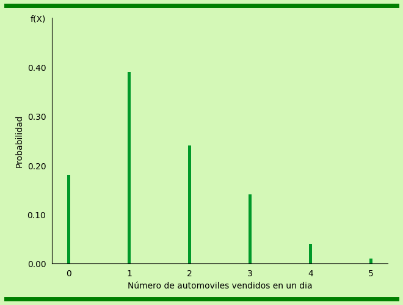

x. El ejemplo más sencillo de una distribución de probabilidad discreta dada una fórmula, es la distribución de probabilidad uniforme discreta. Su función de probabilidad se defi ne por medio de la ecuación (5.3).

FUNCIÓN DE PROBABILIDAD UNIFORME DISCRETA

f(x) = 1/n

(5.3)

donde:

$$\scriptsize n = \text{número de valores que la variable aleatoria puede asumir.}$$

Por ejemplo, suponga que para el experimento de lanzar un dado la variable aleatoria x se defi ne como el número de puntos en la cara que queda hacia arriba. Para este experimento, n = 6 valores son posibles para la variable aleatoria; x = 1, 2, 3, 4, 5, 6. Por tanto, la función de probabilidad para esta variable aleatoria uniforme discreta es

$$ f (x) = 1/6\quad x = 1, 2, 3, 4, 5, 6 $$

Los valores posibles de la variable aleatoria y las probabilidades asociadas se muestran en seguida.

| x | f(x) |
| --- | --- |
| 1 | 1/6 |
| 2 | 1/6 |
| 3 | 1/6 |
| 4 | 1/6 |
| 5 | 1/6 |
| 6 | 1/6 |

Como otro ejemplo, considere la variable aleatoria x con la distribución de probabilidad siguiente.

| x | f(x) |
| --- | --- |
| 1 | 1/10 |
| 2 | 2/10 |
| 3 | 3/10 |
| 4 | 4/10 |

Esta distribución de probabilidad se defi ne por medio de la fórmula

$$ f(x) = \frac{x}{10} \quad para \,\, x = 1, 2, 3\, o \,\,4 $$

La evaluación de $f (x)$ para un valor dado de la variable aleatoria proporciona la probabilidad asociada. Por ejemplo, usando la función de probabilidad anterior, vemos que $f (2)$ = 2/10 proporciona la probabilidad de que la variable aleatoria asuma el valor 2.

Las distribuciones de probabilidad discretas de uso más común por lo general se especifican por medio de fórmulas. Tres casos importantes son las distribuciones binomial, de Poisson e hipergeométrica, las cuales se estudian posteriormente en este capítulo.

## 5.3 **Valor esperado y varianza**

**Valor esperado**

El valor esperado , o media, de una variable aleatoria es una medida de su posición central. La fórmula para el valor esperado de una variable aleatoria discreta x se indica enseguida.

VALOR ESPERADO DE UNA VARIABLE ALEATORIA DISCRETA

E(x) = μ = ∑x f(x)

(5.4)

Ambas notaciones, E(x) y μ se usan para denotar el valor esperado de una variable aleatoria. La ecuación (5.4) muestra que para calcular el valor esperado de una variable aleatoria discreta se debe multiplicar cada valor de la variable por su probabilidad correspondiente f (x), y después se suman los productos que resultan. Utilizando el ejemplo de la venta de automóviles de DiCarlo Motors de la sección 5.2, en la tabla 5.4 se muestra el cálculo del valor esperado para el número de vehículos vendidos durante un día. La suma de las entradas de la columna xf (x) muestra que el valor esperado es 1.50 unidades por día. Por consiguiente, aunque se sabe que en un día cualquiera las ventas pueden ser de 0, 1, 2, 3, 4 o 5 automóviles, DiCarlo anticipa que con el tiempo se venderá un promedio diario de 1.50. Suponiendo que un mes tiene 30 días de operación, se usa el valor esperado de 1.50 para pronosticar el promedio de ventas mensuales de 30(1.50) = 45 vehículos.

**Varianza**

Aun cuando el valor esperado proporciona el valor medio de la variable aleatoria, a menudo necesitamos una medida de variabilidad o dispersión. Así como la varianza se usó en el capítulo 3 para resumir la variabilidad en los datos, ahora la varianza se usa para resumir la variabilidad en los valores de una variable aleatoria. A continuación se presenta la fórmula para la varianza de una variable aleatoria discreta.

VARIANZA DE UNA VARIABLE ALEATORIA DISCRETA

Var(x) = σ² = ∑(x - μ)² f(x)

(5.5)

Como muestra la ecuación (5.5), una parte esencial de la fórmula de la varianza es la desviación, x - μ, la cual mide a qué distancia está el valor esperado, o la media, μ, de un valor particular de la variable aleatoria. Para calcular la varianza de una variable aleatoria, las desviaciones se elevan al cuadrado y luego se ponderan por el valor correspondiente de la función de probabilidad. La suma de estas desviaciones al cuadrado ponderadas para todos los valores de la variable aleatoria se conocen como la varianza. Las notaciones Var (x) y σ2 se usan para denotar la varianza de una variable aleatoria.

**TABLA 5.4** Cálculo del valor esperado para el número de automóviles que se venden en un día en Dicarlo Motors

| x | f (x) | xf (x) |
| --- | --- | --- |
| 0 | 0.18 | 0(0.18) = 0.00 |
| 1 | 0.39 | 1(0.39) = 0.39 |
| 2 | 0.24 | 2(0.24) = 0.48 |
| 3 | 0.14 | 3(0.14) = 0.42 |
| 4 | 0.04 | 4(0.04) = 0.16 |
| 5 | 0.01 | 5(0.01) = 0.05 |
|  |  | 1.50 |

**TABLA 5.5** Cálculo de la varianza para el número de automóviles que se venden en un día en Dicarlo Motors

| $x$ | $x - μ$ | $(x - μ)^2$ | $f(x)$ | $(x-μ)^2 f(x)$ |
| --- | --- | --- | --- | --- |
| $0$ | $0 - 1.50 = -1.50$ | $2.25$ | $0.18$ | $0.4050$ |
| $1$ | $1 - 1.50 = -0.50$ | $0.25$ | $0.39$ | $0.0975$ |
| $2$ | $2 - 1.50 = 0.50$ | $0.25$ | $0.24$ | $0.0600$ |
| $3$ | $3 - 1.50 = 1.50$ | $2.25$ | $0.14$ | $0.3150$ |
| $4$ | $4 - 1.50 = 2.50$ | $6.25$ | $0.04$ | $0.2500$ |
| $5$ | $5 - 1.50 = 3.50$ | $12.25$ | $0.01$ | $0.1225$ |
| $Total$ |  |  |  | $1.2500$ |

El cálculo de la varianza para la distribución de probabilidad del número de automóviles vendidos durante un día en DiCarlo Motors se resume en la tabla 5.5. Vemos que la varianza es 1.25. tiempo La desviación estándar, σ, se defi ne como la raíz cuadrada positiva de la varianza. Por tanto, la desviación estándar para el número de automóviles vendidos durante un día es

$$ \sigma = \sqrt{1.25} = 1.118 $$

La desviación estándar se mide en las mismas unidades que la variable aleatoria ($\sigma = 1.118$ automóviles) y por tanto a menudo se prefi ere para describir la variabilidad de una variable aleatoria. La varianza $\sigma^2$ se mide en unidades cuadradas y, por tanto, es más difícil de interpretar.

## 5.4 **Distribución de probabilidad binomial**

La distribución de probabilidad binomial es una distribución de probabilidad discreta que proporciona muchas aplicaciones. Se asocia con un experimento de múltiples pasos que se llama *experimento binomial*.

**Un experimento binomial.**

Un experimento binomial tiene las cuatro propiedades siguientes.

PROPIEDADES DE UN EXPERIMENTO BINOMIAL

1. El experimento consiste de una secuencia de $n$ ensayos idénticos.
2. En cada ensayo hay dos resultados posibles. A uno de ellos se le llama éxito y al otro, fracaso.
3. La probabilidad de éxito, denotada por p, no cambia de un ensayo a otro. Por consiguiente, la probabilidad de fracaso, denotada por $1 - p$, tampoco cambia de un ensayo a otro.
4. Los ensayos son independientes.

En un experimento binomial, lo que interesa es el número de éxitos que ocurren en los n ensayos. Si x denota el número de éxitos que ocurren en n ensayos, vemos que x puede asumir los valores 0, 1, 2, 3..., n. Debido a que el número de valores es fi nito, x es una variable aleatoria discreta. La distribución de probabilidad asociada con esta variable se llama Un distribución de probabilidad binomial. Por ejemplo, considere el experimento de lanzar una moneda cinco veces y en cada lanzamiento observe si la moneda cae con cara o cruz en el lado superior. Suponga que queremos contar el número de caras que aparecen durante los cinco lanzamientos. ¿Este ejemplo muestra las propiedades de un experimento binomial? ¿Cuál es la variable aleatoria de interés? Observe que:

1. El experimento consta de cinco ensayos idénticos; cada uno consiste en el lanzamiento de una moneda.
2. En cada ensayo hay dos resultados posibles: cara o cruz. Se puede designar cara como un éxito y cruz como un fracaso.
3. La probabilidad de obtener cara y la probabilidad de obtener cruz son iguales para cada ensayo, con $p = 0.5$ y $1 - p = 0.5$.
4. Los ensayos o lanzamientos son independientes debido a que el resultado de cualquier ensayo no se ve afectado por lo que ocurre con otros ensayos o lanzamientos.

[output not shown]

Por tanto, las propiedades de un experimento binomial se satisfacen. La variable aleatoria que interesa es x = número de caras que ocurren en cinco ensayos. En este caso, x puede tomar los valores 0, 1, 2, 3, 4 o 5.

En otro ejemplo, considere a una vendedora de seguros que visita a 10 familias seleccionadas al azar. El resultado asociado con cada visita se clasifi ca como un éxito si la familia compra un seguro y un fracaso si no lo compra. A partir de su experiencia, la vendedora sabe que la probabilidad de que una familia seleccionada al azar compre un seguro es de 0.10. Al revisar las propiedades de un experimento binomial se observa que:

1. El experimento consta de 10 ensayos idénticos; cada uno consiste en visitar a una familia.
2. En cada ensayo hay dos resultados posibles: la familia compra el seguro (éxito) o no lo compra (fracaso)
3. Se asume que las probabilidades de que haya una compra o no la haya son iguales para cada visita, con $p = 0.10$ y $1 - p = 0.90$.
4. Los ensayos son independientes, porque las familias se eligen al azar.

Como estos cuatro supuestos se cumplen, este ejemplo es un experimento binomial. La variable aleatoria de interés es el número de ventas obtenidas al hacer contacto con las 10 familias. En este caso, x puede asumir los valores 0, 1, 2, 3, 4, 5, 6, 7, 8, 9 y 10.

La propiedad 3 del experimento binomial se llama supuesto de estacionariedad y a veces se confunde con la propiedad 4, la independencia de los ensayos. Para ver cómo difi eren, considere de nuevo el caso de la vendedora que visita a las familias para ofrecer seguros. Si, a medida que el día avanza, la empleada se cansa y pierde entusiasmo, la probabilidad de éxito (vender un seguro) para el décimo contacto podría disminuir a 0.05, por ejemplo. En este caso, la propiedad 3 (estacionariedad) no se cumpliría y el experimento no sería binomial. Incluso si la propiedad 4 se cumple, es decir, que las decisiones de compra de cada familia se realizaran en forma independiente, el experimento no sería binomial si la propiedad 3 no se satisface.

En las aplicaciones con experimentos binomiales se usa una fórmula matemática especial, llamada función de probabilidad binomial, para calcular la probabilidad de x éxitos en n ensayos. Enseguida se mostrará cómo se desarrolla la fórmula, en el contexto de un problema ilustrativo, usando los conceptos de probabilidad presentados en el capítulo 4.

**El problema de Big Sur**

Considere las decisiones de compra de los tres clientes siguientes que entran en la tienda de ropa Big Sur. Con base en su experiencia, el gerente de la tienda estima que la probabilidad de que un cliente cualquiera haga una compra es de 0.30. ¿Cuál es la probabilidad de que dos de los tres clientes siguientes realicen una compra?

El experimento de observar a tres clientes que toman una decisión de compra, cada uno tiene ocho resultados posibles. Si S denota éxito (una compra) y F denota fracaso (no hay compra), se tiene interés en los resultados experimentales que consisten en dos éxitos en los tres ensayos (decisiones de compra). A continuación se verificará que el experimento con una secuencia de tres decisiones de compra puede verse como binomial. Al revisar los cuatro requerimientos para un experimento binomial observamos que:

1. El experimento se describe como una secuencia de tres ensayos idénticos, uno para cada uno de los tres clientes que entran en la tienda.
2. Para cada ensayo hay dos resultados posibles: el cliente efectúa una compra (éxito) o el cliente no efectúa una compra (fracaso).
3. Se asume que la probabilidad de que el cliente realice una compra (0.30) o no la realice (0.70) es la misma para todos los clientes.
4. La decisión de compra de cada sujeto es independiente de las decisiones que tomen los otros clientes.

Por consiguiente, están presentes las propiedades de un experimento binomial. El número de resultados experimentales que producen exactamente x éxitos en n ensayo se calcula usando la fórmula siguiente.

NÚMERO DE RESULTADOS EXPERIMENTALES QUE PROPORCIONAN EXACTAMENTE $x$ ÉXITOS EN $n$ ENSAYOS

\binom{n}{x} = \frac{n!}{x!(n-x)!}

(5.6)

y por definicion,

0! = 1

Ahora regresemos al experimento de Big Sur que consiste en las decisiones de compra de tres clientes. La ecuación (5.6) permite determinar el número de resultados que involucran dos compras; es decir, el número de maneras de obtener $x = 2$ éxitos en $n = 3$ ensayos. A partir de la ecuación (5.6) tenemos

$$ \binom{n}{x} = \binom{3}{2} = \frac{3!}{2!(3-2)!} = \frac{3!}{2!\cdot1!} = \frac{3\cdot2\cdot1}{2\cdot1\cdot1} = \frac{6}{2} = 3 $$

La ecuación $(5.6)$ muestra que tres de los resultados experimentales produjeron dos éxitos.

Usando la ecuación $(5.6)$ para determinar cuántos resultados experimentales tienen tres éxitos (compras) en los tres ensayos, obtenemos

$$ \binom{n}{x} = \binom{3}{3} = \frac{3!}{3!(3-3)!} = \frac{3!}{3!\cdot0!} = \frac{3\cdot2\cdot1}{3\cdot2\cdot1\cdot1} = \frac{6}{6} = 1 $$

Se sabe que la ecuación $(5.6)$ se utiliza para determinar el número de resultados experimentales que dan lugar a $x$ éxitos. Si se determinará la probabilidad de x éxitos en n ensayos, no obstante, también debemos conocer la probabilidad asociada con cada uno de estos resultados. Como los ensayos de un experimento binomial son independientes, sencillamente es posible multiplicar las probabilidades asociadas con el resultado de cada ensayo para encontrar la probabilidad de una secuencia particular de éxitos y fracasos.

La probabilidad de que los dos primeros clientes compren y que el tercero no compre, denotada por $(S, S, F)$, está dada por:

$$ pp(1-p) $$

Con una probabilidad de $0.30$ de una compra en cualquier ensayo, la probabilidad de una compra en los primeros dos ensayos y ninguna compra en el tercero está dada por:

$$(0.30)(0.30)(0.70) = (0.30)^2(0.70) = 0.063$$

Otros dos resultados experimentales también dan lugar a dos éxitos y un fracaso. Las probabilidades de tres resultados que tienen dos éxitos se presentan a continuación.

**RESULTADOS DE LOS ENSAYOS**

[output not shown]

Observe que los tres resultados experimentales con dos éxitos tienen exactamente la misma probabilidad. Esta observación es válida en general. En cualquier experimento binomial, todas las secuencias de resultados de ensayos que producen $x$ éxitos en $n$ ensayos tienen la misma probabilidad de ocurrencia. La probabilidad de cada secuencia de ensayos que producen $x$ éxitos en $n$ ensayos se presenta a continuación.

$$\begin{align*} \text{Probabilidad de una secuencia}\\ \text{particular de resultados de} =p^x(1-p)^{(n-x)}\\ \text{con x éxitos en n ensayos} \end{align*}$$

En el caso de la tienda Martin Clothing Store, esta fórmula indica que cualquier resultado experimental con dos éxitos tiene una probabilidad de $p^2(1 - p)^{(3-2)} = p^2(1 - p)^1 = (0.30)^2(0.70)^1 = 0.063$.

Como la ecuación $(5.6)$ muestra el número de resultados de un experimento binomial con $x$ éxitos y la ecuación $(5.7)$ proporciona la probabilidad de cada secuencia con $x$ éxitos, las ecuaciones $(5.6)$ y $(5.7)$ se combinan para obtener la función de probabilidad binomial siguiente.

FUNCIÓN DE PROBABILIDAD BINOMIAL

f(x)=\binom{n}{x}p^x(1-p)^{(n-x)}

(5.8)

donde:

$$\scriptsize x=\text{número de éxitos}$$ $$\scriptsize p=\text{probabilidad de un éxito en un ensayo}$$ $$\scriptsize n=\text{número de ensayos}$$ $$\scriptsize f(x)=\text{probabilidad de}\; x \;\text{éxitos en}\; n\; \text{ensayos}$$ $$\scriptsize \binom{n}{x}=\frac{n!}{x!(n-x)!}$$

Para la distribución de probabilidad binomial, x es una variable aleatoria discreta con la función de probabilidad $f(x)$ aplicable para los valores de $x = 0, 1, 2,..., n$.

En el ejemplo de Martin Clothing Store, se usa la ecuación $(5.8)$ para calcular la probabilidad de que ningún cliente realice una compra; exactamente un cliente haga una compra; exactamente dos clientes efectúen una compra, y los tres clientes compren. Los cálculos se resumen en la tabla $5.6$, que proporciona la distribución de probabilidad del número de sujetos que realizan una compra. La figura $5.4$ es una gráfica de esta distribución de probabilidad.

La función de probabilidad binomial se aplica a cualquier experimento binomial. Si una situación demuestra las propiedades de un experimento binomial y se conocen los valores de $n$ y $p$, se puede usar la ecuación $(5.8)$ para calcular la probabilidad de $x$ éxitos en $n$ ensayos.

**TABLA 5.6** Distribución de probabilidad para el número de clientes que efectúan una compra

| x | f(x) |
| --- | --- |
| 0 | \frac{3!}{0!3!}(0.30)^0(0.70)^3=0.343 |
| 1 | \frac{3!}{1!2!}(0.30)^1(0.70)^2=0.441 |
| 2 | \frac{3!}{2!1!}(0.30)^2(0.70)^1=0.189 |
| 3 | \frac{3!}{3!0!}(0.30)^3(0.70)^0=\dfrac{0.027}{1.000} |

**FIGURA 5.4** Representación gráfica de la distribución de probabilidad para el número de clientes que efectúan una compra

```python
import matplotlib.pyplot as plt

# Datos de ejemplo
categorias = ['0', '1', '2', '3']
valores = [0.343, 0.441, 0.189, 0.027]

# Define color de las barras
color_hex = '#009929'

# Crear el gráfico de barras con espacio reducido entre categorías
fig, ax = plt.subplots()
bars = ax.bar(categorias, valores, color=color_hex, width=0.03)

# Ajustar el espacio entre las categorías y quitar las líneas de arriba y a la derecha
ax.spines['top'].set_visible(False)
ax.spines['right'].set_visible(False)
ax.xaxis.set_tick_params(width=0)  # Ocultar las líneas del eje x
ax.yaxis.set_tick_params(width=0)  # Ocultar las líneas del eje y

# Ajustar el color de fondo dentro de la gráfica a verde claro
ax.set_facecolor('#d4f8b7')  # Código hexadecimal para verde claro

# Ajustar el color de fondo de la figura a verde
fig.set_facecolor('#d4f8b7')  # Código hexadecimal para verde

# Añadir líneas superior e inferior
linea_superior = plt.Line2D((0, 1), (1, 1), color='green', linewidth=5, transform=fig.transFigure)
linea_inferior = plt.Line2D((0, 1), (0, 0), color='green', linewidth=5, transform=fig.transFigure)
fig.lines.extend([linea_superior, linea_inferior])

# Ajustar el espacio entre las categorías y quitar las líneas de arriba y a la derecha
ubicaciones_y = [0.00, 0.10, 0.20, 0.30, 0.40, 0.50]
etiquetas_y = ['0.00', '0.10', '0.20', '0.30', '0.40', '0.50']
ax.set_yticks(ubicaciones_y)
ax.set_yticklabels(etiquetas_y)

# Agregar etiquetas y título
plt.xlabel('Número de clientes que efectúan una compra   x')
plt.ylabel('Probabilidad   f(x)')
# plt.title('Gráfico de Barras sin Líneas en la Parte Superior y Derecha')

# Mostrar el gráfico
plt.tight_layout()  # Ajustar el diseño para evitar cortar las etiquetas
plt.show()
```

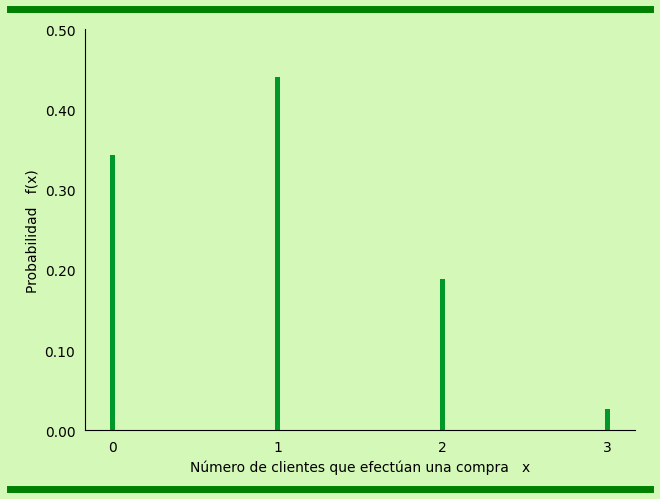

Si se consideran variaciones del experimento de Big Sur, por ejemplo que *10 clientes en vez de tres entren en la tienda*, la función de probabilidad binomial dada la ecuación $(5.8)$ sigue siendo válida. Suponga que se tiene un experimento binomial con $n=10, x=4\;y\;p=0.30$. La probabilidad de que exactamente cuatro de los 10 clientes que entran en la tienda realicen una compra es:

$$f(4)=\dfrac{10!}{4!6!}(0.30)^4(0.70)^6=0.2001$$

**TABLA 5.7** Valores seleccionados del ejemplo de la tabla de probabilidad binomial: $n=10;\;x=3;\;p=0.040;\;f(3)=0.2150$

| p | p | p | p | p | p | p | p | p | p | p | p |
| --- | --- | --- | --- | --- | --- | --- | --- | --- | --- | --- | --- |
| n | x | 0.05 | 0.10 | 0.15 | 0.20 | 0.25 | 0.30 | 0.35 | 0.40 | 0.45 | 0.50 |
| 9 | 0 | 0.6302 | 0.3874 | 0.2316 | 0.1342 | 0.0751 | 0.0404 | 0.0207 | 0.0101 | 0.0046 | 0.0020 |
|  | 1 | 0.2985 | 0.3874 | 0.3679 | 0.3020 | 0.2253 | 0.1556 | 0.1004 | 0.0605 | 0.0339 | 0.0176 |
|  | 2 | 0.0629 | 0.1722 | 0.2597 | 0.3020 | 0.3003 | 0.2668 | 0.2162 | 0.1612 | 0.1110 | 0.0703 |
|  | 3 | 0.0077 | 0.0446 | 0.1069 | 0.1762 | 0.2336 | 0.2668 | 0.2716 | 0.2508 | 0.2119 | 0.1641 |
|  | 4 | 0.0006 | 0.0074 | 0.0283 | 0.0661 | 0.1168 | 0.1715 | 0.2194 | 0.2508 | 0.2600 | 0.2461 |
|  | 5 | 0.0000 | 0.0008 | 0.0050 | 0.0165 | 0.0389 | 0.0735 | 0.1181 | 0.1672 | 0.2128 | 0.2461 |
|  | 6 | 0.0000 | 0.0001 | 0.0006 | 0.0028 | 0.0087 | 0.0210 | 0.0424 | 0.0743 | 0.1160 | 0.1641 |
|  | 7 | 0.0000 | 0.0000 | 0.0000 | 0.0003 | 0.0012 | 0.0039 | 0.0098 | 0.0212 | 0.0407 | 0.0703 |
|  | 8 | 0.0000 | 0.0000 | 0.0000 | 0.0000 | 0.0001 | 0.0004 | 0.0013 | 0.0035 | 0.0083 | 0.0176 |
|  | 9 | 0.0000 | 0.0000 | 0.0000 | 0.0000 | 0.0000 | 0.0000 | 0.0001 | 0.0003 | 0.0008 | 0.0020 |
| 10 | 0 | 0.5987 | 0.3487 | 0.1969 | 0.1074 | 0.0563 | 0.0282 | 0.0135 | 0.0060 | 0.0025 | 0.0010 |
|  | 1 | 0.3151 | 0.3874 | 0.3474 | 0.2684 | 0.1877 | 0.1211 | 0.0725 | 0.0403 | 0.0207 | 0.0098 |
|  | 2 | 0.0746 | 0.1937 | 0.2759 | 0.3020 | 0.2816 | 0.2335 | 0.1757 | 0.1209 | 0.0763 | 0.0439 |
|  | 3 | 0.0105 | 0.0574 | 0.1298 | 0.2013 | 0.2503 | 0.2668 | 0.2522 | 0.2150 | 0.1665 | 0.1172 |
|  | 4 | 0.0010 | 0.0112 | 0.0401 | 0.0881 | 0.1460 | 0.2001 | 0.2377 | 0.2508 | 0.2384 | 0.2051 |
|  | 5 | 0.0001 | 0.0015 | 0.0085 | 0.0264 | 0.0584 | 0.1029 | 0.1536 | 0.2007 | 0.2340 | 0.22461 |
|  | 6 | 0.0000 | 0.0001 | 0.0012 | 0.0055 | 0.0162 | 0.0368 | 0.0689 | 0.1115 | 0.1596 | 0.2051 |
|  | 7 | 0.0000 | 0.0000 | 0.0001 | 0.0008 | 0.0031 | 0.0090 | 0.0212 | 0.0425 | 0.0746 | 0.1172 |
|  | 8 | 0.0000 | 0.0000 | 0.0000 | 0.0001 | 0.0004 | 0.0014 | 0.0043 | 0.0106 | 0.0229 | 0.0439 |
|  | 9 | 0.0000 | 0.0000 | 0.0000 | 0.0000 | 0.0000 | 0.0001 | 0.0005 | 0.0016 | 0.0042 | 0.0098 |
|  | 10 | 0.0000 | 0.0000 | 0.0000 | 0.0000 | 0.0000 | 0.0000 | 0.0000 | 0.0001 | 0.0003 | 0.0010 |

**Valor esperado y varianza de la distribución binomial**

En la sección 5.3 se proporcionaron las fórmulas para calcular el valor esperado y la varianza de una variable aleatoria discreta. En el caso especial en que la variable tiene una distribución binomial con un número conocido de ensayos n y una probabilidad conocida de éxitos p, las fórmulas generales para el valor esperado y la varianza se simplifican. Los resultados se muestran a continuación.

VALOR ESPERADO Y VARIANZA DE LA DISTRIBUCION BINOMIAL

E(x)= μ=np

(5.9)

Var(x)=σ^2=np(1-p)

(5.10)

**FIGURA 5.5** Resultado que muestra las probabilidades binomiales para el problema

| x | P(X=x) |
| --- | --- |
| 0.00 | 0.0282 |
| 1.00 | 0.1211 |
| 2.00 | 0.2335 |
| 3.00 | 0.2668 |
| 4.00 | 0.2001 |
| 5.00 | 0.1029 |
| 6.00 | 0.0368 |
| 7.00 | 0.0090 |
| 8.00 | 0.0014 |
| 9.00 | 0.0001 |
| 10.00 | 0.0000 |

En el caso del problema de Martin Clothing Store con tres clientes, se usa la ecuación $(5.9)$ para calcular el número esperado de clientes que realizarán una compra.

$$E(x)=np=3(0.30)=0.9$$

Suponga que para el mes siguiente Martin Clothing Store pronostica que 1000 clientes entrarán en la tienda. ¿Cuál es el número esperado de personas que realizarán una compra? La respuesta es $μ=np=(1000)(0.3)=300$. Por tanto, para aumentar el número esperado de compras, la empresa debe lograr que más clientes entren en el establecimiento y/o aumentar de alguna manera la probabilidad de que un cliente realice una compra cuando esté adentro. En este problema con tres clientes, vemos que la varianza y la desviación estándar del número de ellos que harán una compra es:

$$σ^2=np(1-p)=3(0.3)(0.7)=0.63$$ $$σ=\sqrt{0.63}=0.79$$

Para los próximos 1000 clientes que entren en la tienda, la varianza y la desviación estándar del número de personas que harán una compra son:

$$σ^2=np(1-p)=1000(0.3)(0.7)=210$$ $$σ=\sqrt{210}=14.49$$

### NOTAS Y COMENTARIOS

1. La tabla binomial del apéndice B muestra valores de p hasta p = 0.95, inclusive. Algunas fuentes de la tabla binomial sólo muestran valores de p hasta p = 0.50.Parecería que una tabla como ésta no puede usarse cuando la probabilidad de éxito rebasa p = 0.50. No obstante, puede utilizarse si se considera que la probabilidad de n - x fracasos es también la probabilidad de x éxitos. Por tanto, cuando la probabilidad de éxito es mayor que p = 0.50, se calcula la probabilidad de n - x fracasos en vez de la probabilidad de éxitos. La probabilidad de fracasos, 1 - p, es menor que 0.50 cuando p > 0.50. 2. Algunas fuentes presentan las tablas binomiales en forma acumulada. Al usarlas para encontrar exactamente x éxitos en n ensayos, se deben restar las entradas de la tabla correspondiente. Por ejemplo, f (2) = P(x ≤ 2) - P(x ≤ 1). La tabla binomial del apéndice B proporciona f (2) directamente. Para calcular las probabilidades acumuladas usando las tablas binomiales del apéndice B, se suman las entradas de la tabla correspondiente. Por ejemplo, para determinar la probabilidadacumulada P(x ≤ 2), calcule la suma f (0) + f (1) + f (2).

## 5.5 **Distribución de probabilidad de Poisson**

En esta sección consideramos una variable aleatoria discreta que a menudo es útil para estimar el número de ocurrencias en un intervalo específi co de tiempo o espacio. Por ejemplo, la variable aleatoria de interés podría ser el número de llegadas a un centro de lavado automotriz en una hora, el número de reparaciones necesarias en 10 millas de una autopista o el número de fugas en 100 millas de tubería. Si las dos propiedades siguientes se satisfacen, el número de ocurrencias es una variable aleatoria descrita por la distribución de probabilidad de Poisson.

PROPIEDADES DE UN EXPERIMENTO DE POISSON

1. La probabilidad de ocurrencia es la misma para cualesquiera dos intervalos de igual longitud. 2. La ocurrencia o no ocurrencia en cualquier intervalo es independiente de la ocurrencia o no ocurrencia en cualquier otro intervalo.

La función de probabilidad de Poisson se defi ne por medio de la ecuación (5.11).

f(x) = \frac{(μ^x) * e^(-μ)}{x!}

(5.11)

donde:

$$\scriptsize f (x) =\text{probabilidad de x ocurrencias en un intervalo}$$ $$\scriptsize μ = \text{valor esperado o número medio de ocurrencias en un intervalo}$$ $$\scriptsize e = \text{2.71828}$$

Para la distribución de probabilidad de Poisson, x es una variable aleatoria discreta que indica el número de ocurrencias en el intervalo. Como no hay un límite superior establecido para el número de ocurrencias, la función de probabilidad f (x) es aplicable para los valores x = 0, 1, 2, . . . sin límite. En las aplicaciones prácticas, x a la larga se volverá lo sufi cientemente grande para que f (x) sea aproximadamente cero y la probabilidad de cualquier valor mayor que x se vuelva insignifi cante.

**Un ejemplo con intervalos de tiempo**

Suponga que le interesa conocer el número de llegadas al autocajero de un banco en las mañanas de lunes a viernes durante un periodo de 15 minutos. Si se asume que la probabilidad de un automóvil que llega es la misma para cualquiera de dos periodos de igual duración y que la llegada o no llegada de un vehículo en cualquier periodo es independiente del arribo o no en cualquier otro periodo, la función de probabilidad de Poisson es aplicable. Suponga que estos supuestos se cumplen y que un análisis de los datos históricos muestra que el número medio de automóviles que llega en un periodo de 15 minutos es 10; en este caso, se aplica la función de probabilidad siguiente.

$$ f(x)= \frac{10^x*e^{-10}}{x!} $$

La variable aleatoria aquí es x = número de automóviles que llega en un periodo de 15 minutos. Si la gerencia quisiera conocer la probabilidad de exactamente cinco llegadas en 15 minutos, se establecería que x = 5 y por tanto obtendríamos

Probabilidad de exactamente cinco llegadas en 15 minutos

$$ f(5)= \frac{10^5*e^{-10}}{5!} $$

Aunque esta probabilidad se determinó al evaluar la función de probabilidad con μ = 10 y x = 5, a menudo es más fácil remitirse a una tabla para la distribución de Poisson, la cual proporciona probabilidades para valores específi cos de x y μ. Se incluyó una similar a la tabla 7 del apéndice B. Por conveniencia, reproducimos una parte de ésta en la tabla 5.8. Observe que para usar la tabla de probabilidades de Poisson necesitamos conocer sólo los valores de x y μ. A partir de la tabla 5.8 vemos que la probabilidad de cinco llegadas en un periodo de 15 minutos se encuentra ubicando el valor en la fi la de la tabla que corresponde a x = 5 y la columna que corresponde a μ = 10. Por consiguiente, obtenemos f (5) = 0.0378. En el ejemplo anterior, la media de la distribución de Poisson es μ = 10 llegadas por un periodo de 15 minutos. Una propiedad de la distribución de Poisson consiste en que la media de la distribución y la varianza de la distribución son iguales. Por tanto, la varianza para el número de llegadas durante un periodo de 15 minutos es $σ^2 = 10$. La desviación estándar es $σ = \sqrt(10) =$ 3.16. El ejemplo involucra un periodo de 15 minutos, pero se pueden usar otros. Suponga que se quiere calcular la probabilidad de una llegada en un periodo de 3 minutos. Dado que 10 es el número esperado de llegadas en 15 minutos, vemos que 10/15 = 2/3 es el número esperado de llegadas en 1 minuto y que (2/3)(3 minutos) = 2 es el número esperado de arribos en 3 minutos. Por tanto, la probabilidad de x llegadas en un periodo de 3 minutos con μ = 2 está dada por la función de probabilidad de Poisson siguiente.

$$ f(x)= \frac{2^x*e^{-2}}{x!} $$

**TABLA 5.8** de las tablas de probabilidad de Poisson: $μ=10;\;x=5;\;f(5)=0.0378$

| μ | μ | μ | μ | μ | μ | μ | μ | μ | μ | μ | μ |
| --- | --- | --- | --- | --- | --- | --- | --- | --- | --- | --- | --- |
| x | 9.1 | 9.2 | 9.3 | 9.4 | 9.5 | 9.6 | 9.7 | 9.8 | 9.9 | 10 |  |
| 0 | 0.0001 | 0.0001 | 0.0001 | 0.0001 | 0.0001 | 0.0001 | 0.0001 | 0.0001 | 0.0001 | 0.0000 |  |
| 1 | 0.0010 | 0.0009 | 0.0009 | 0.0008 | 0.0007 | 0.0007 | 0.0006 | 0.0005 | 0.0005 | 0.0005 |  |
| 2 | 0.0046 | 0.0043 | 0.0040 | 0.0037 | 0.0034 | 0.0031 | 0.0029 | 0.0027 | 0.0025 | 0.0023 |  |
| 3 | 0.0140 | 0.0131 | 0.0123 | 0.0115 | 0.0107 | 0.0100 | 0.0093 | 0.0087 | 0.0081 | 0.0076 |  |
| 4 | 0.0319 | 0.0302 | 0.0285 | 0.0269 | 0.0254 | 0.0240 | 0.0226 | 0.0213 | 0.0201 | 0.0189 |  |
| 5 | 0.0581 | 0.0555 | 0.0530 | 0.0506 | 0.0483 | 0.0460 | 0.0439 | 0.0418 | 0.0398 | 0.0378 |  |
| 6 | 0.0881 | 0.0851 | 0.0822 | 0.0793 | 0.0764 | 0.0736 | 0.0709 | 0.0682 | 0.0656 | 0.0631 |  |
| 7 | 0.1145 | 0.1118 | 0.1091 | 0.1064 | 0.1037 | 0.1010 | 0.0982 | 0.0955 | 0.0928 | 0.0901 |  |
| 8 | 0.1302 | 0.1286 | 0.1269 | 0.1251 | 0.1232 | 0.1212 | 0.1191 | 0.1170 | 0.1148 | 0.1126 |  |
| 9 | 0.1317 | 0.1315 | 0.1311 | 0.1306 | 0.1300 | 0.1293 | 0.1284 | 0.1274 | 0.1263 | 0.1251 |  |
| 10 | 0.1198 | 0.1210 | 0.1219 | 0.1228 | 0.1235 | 0.1241 | 0.1245 | 0.1249 | 0.1250 | 0.1251 |  |
| 11 | 0.0991 | 0.1012 | 0.1031 | 0.1049 | 0.1067 | 0.1083 | 0.1098 | 0.1112 | 0.1125 | 0.1137 |  |
| 12 | 0.0752 | 0.0776 | 0.0799 | 0.0822 | 0.0844 | 0.0866 | 0.0888 | 0.0908 | 0.0928 | 0.0948 |  |
| 13 | 0.0526 | 0.0549 | 0.0572 | 0.0594 | 0.0617 | 0.0640 | 0.0662 | 0.0685 | 0.0707 | 0.0729 |  |
| 14 | 0.0342 | 0.0361 | 0.0380 | 0.0399 | 0.0419 | 0.0439 | 0.0459 | 0.0479 | 0.0500 | 0.0521 |  |
| 15 | 0.0208 | 0.0221 | 0.0235 | 0.0250 | 0.0265 | 0.0281 | 0.0297 | 0.0313 | 0.0330 | 0.0347 |  |
| 16 | 0.0118 | 0.0127 | 0.0137 | 0.0147 | 0.0157 | 0.0168 | 0.0180 | 0.0192 | 0.0204 | 0.0217 |  |
| 17 | 0.0063 | 0.0069 | 0.0075 | 0.0081 | 0.0088 | 0.0095 | 0.0103 | 0.0111 | 0.0119 | 0.0128 |  |
| 18 | 0.0032 | 0.0035 | 0.0039 | 0.0042 | 0.0046 | 0.0051 | 0.0055 | 0.0060 | 0.0065 | 0.0071 |  |
| 19 | 0.0015 | 0.0017 | 0.0019 | 0.0021 | 0.0023 | 0.0026 | 0.0028 | 0.0031 | 0.0034 | 0.0037 |  |
| 20 | 0.0007 | 0.0008 | 0.0009 | 0.0010 | 0.0011 | 0.0012 | 0.0014 | 0.0015 | 0.0017 | 0.0019 |  |
| 21 | 0.0003 | 0.0003 | 0.0004 | 0.0004 | 0.0005 | 0.0006 | 0.0006 | 0.0007 | 0.0008 | 0.0009 |  |
| 22 | 0.0001 | 0.0001 | 0.0002 | 0.0002 | 0.0002 | 0.0002 | 0.0003 | 0.0003 | 0.0004 | 0.0004 |  |
| 23 | 0.0000 | 0.0001 | 0.0001 | 0.0001 | 0.0001 | 0.0001 | 0.0001 | 0.0001 | 0.0002 | 0.0002 |  |
| 24 | 0.0000 | 0.0000 | 0.0000 | 0.0000 | 0.0000 | 0.0000 | 0.0000 | 0.0001 | 0.0001 | 0.0001 |  |

La probabilidad de una llegada en un periodo de 3 minutos se calcula como sigue:

Probabilidad de exactamente 1 llegada en 3 minutos

$$ f(1)= \frac{2^1*e^{-2}}{1!} $$

Previamente se calculó la probabilidad de cinco llegadas en un periodo de 15 minutos; fue 0.0378. Observe que la probabilidad de un arribo en 3 minutos (0.2707) no es la misma. Cuando se estima una probabilidad de Poisson para un intervalo de tiempo distinto, primero se debe convertir la tasa media de llegadas al periodo de interés y luego calcular la probabilidad.

**Un ejemplo con intervalos de longitud o de distancia**

Se demostrará una aplicación que no tiene intervalos de tiempo en la que es útil la distribución de Poisson. Suponga que le interesa saber cuál es la ocurrencia de defectos importantes en una autopista un mes después de repavimentarla. Considere que la probabilidad de un defecto es la misma en cualquiera de dos intervalos de igual longitud de la autopista, y que la ocurrencia o no ocurrencia de defectos en cualquier intervalo es independiente de su ocurrencia o no en cualquier otro intervalo. Por ende, la distribución de Poisson puede aplicarse. Suponga que se enteró de que los principales defectos después de un mes de repavimentar ocurren a una tasa media de 2 por milla. En seguida se determinará la probabilidad de que no hay defectos importantes en un tramo particular de 3 millas de la autopista. Como nos interesa un intervalo con esta longitud, μ = (2 defectos/milla)(3 millas) = 6 representa el número esperado de anomalías importantes en este tramo de la autopista. Mediante la ecuación (5.11), la probabilidad de que no haya alguna avería importante es $ f (0) = 0.0025. Por tanto, es poco probable que ningún defecto importante se presente en la sección de las 3 millas. De hecho, este ejemplo indica que 1 - 0.0025 = 0.9975 es la probabilidad de por lo menos un defecto importante en la sección de 3 millas de la autopista.